### Swiftkey Prediction Project - Milestone Report

**Frank D. Evans**  
**Data Science Specialization - Johns Hopkins University**

**Intro:** The overall goal of this project is to create a text prediction system similar to the SwiftKey keyboard application for the Android Mobile platform. This analysis is a Milestone Report on Data Handling, Exploratory Data Analysis, Model Design, and planned Application Architecture.

**Exploratory Data Analysis**

*Load Data*

```r
news <- scan(file = './data/en_US.news.txt', what = 'character', sep = '\n')
blogs <- scan(file = './data/en_US.blogs.txt', what = 'character', sep = '\n')
twitter <- scan(file = './data/en_US.twitter.txt', what = 'character', sep = '\n', skipNul = TRUE)
```

*Clean Corpus Contents and Calculate Word Counts*

```r
library(stringr)
clean_corpus <- function(corpus) {
    output <- tolower(corpus)
    output <- str_replace_all(output, pattern = "'", replacement = "")
    output <- str_replace_all(output, pattern = "[^[:print:]]", replacement = "")
    output <- str_replace_all(output, pattern = "[^[:alpha:] | [:space:]]", replacement = "")
    output <- str_trim(output, side = 'both')
    output <- str_replace_all(output, pattern = " {2,}", replacement = " ")
    output <- str_split(output, pattern = "[[:space:]]")
    output
}
news_clean <- clean_corpus(news)
blogs_clean <- clean_corpus(blogs)
twitter_clean <- clean_corpus(twitter)

doc_counts <- c(length(news), length(blogs), length(twitter))
word_counts <- c(length(unlist(news_clean)),
                 length(unlist(blogs_clean)),
                 length(unlist(twitter_clean)))
eda_df <- data.frame(corpus_name = c('news','blogs','twitter'),
                     doc_counts = doc_counts,
                     word_counts = word_counts)
eda_df$avg_doc_length <- word_counts / doc_counts
eda_df
```

```
##   corpus_name doc_counts word_counts avg_doc_length
## 1        news    1010242    33535452          33.20
## 2       blogs     899288    36886284          41.02
## 3     twitter    2360148    29413068          12.46
```

Before statistics are calculated, documents are cleaned to cast all characters to lowercase, remove all punctuation (but leave cohesive words together), strip out any excess whitespace, and split the documents into words. The twitter corpus contains the most documents by a large margin, while the news and blogs are roughly equivalent. However, there is a considerable difference in the average word count among the three corpus sets, with the blogs averaging the largest number of words per document.

*Overall Word Frequency*

```r
word_freq_all <- read.table(file = './data/int_word_freq_all.csv',
                            header = TRUE, sep = '|', stringsAsFactors = FALSE)
head(word_freq_all)
```

```
##     v   count probability
## 1 the 4749579     0.04758
## 2  to 2752221     0.02757
## 3 and 2402175     0.02406
## 4   a 2378401     0.02382
## 5  of 2005149     0.02009
## 6  in 1642766     0.01646
```

Load the word frequency data frame from earlier pre-processing. For each word in the combined corpus, the integer count of occurence and the blended probability is calculated. The data frame is sorted by word frequency, so examination of the first few records will demonstrate the structure of the word count data.

```r
length(word_freq_all$probability)
```

```
## [1] 996922
```

```r
sum(word_freq_all$probability[1:150])
```

```
## [1] 0.5059
```

```r
150 / length(word_freq_all$probability)
```

```
## [1] 0.0001505
```

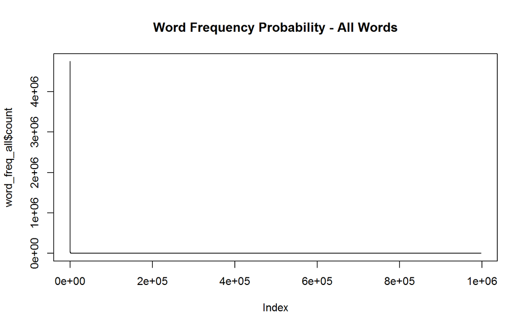

```r
plot(word_freq_all$count, type = 'l', main = "Word Frequency Probability - All Words")
```

When a plot of all word frequencies is used, the long tail is so prevalent that the falloff of the most common words appears to be a veritcal line.

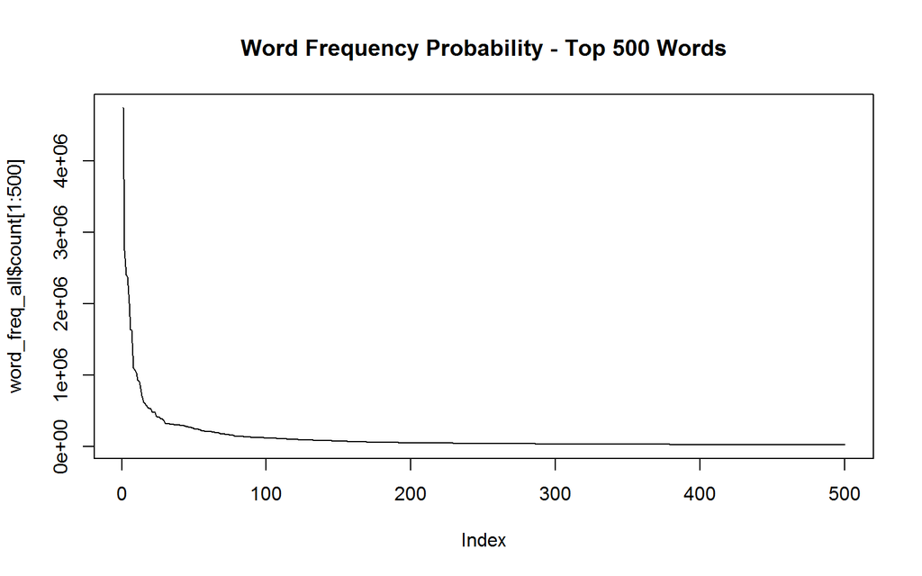

```r
plot(word_freq_all$count[1:500], type = 'l', main = "Word Frequency Probability - Top 500 Words")
```

*Word Tuple Frequency*

```r
word_tuple_n2 <- read.table(file = './data/int_ref_all_n2.csv',
                            header = TRUE, sep = '|', stringsAsFactors = FALSE)
head(word_tuple_n2)
```

```
##       k1   k2   v count probability
## 1    one   of the 34558   0.0007077
## 2      a  lot  of 30010   0.0006146
## 3 thanks  for the 23761   0.0004866
## 4     to   be   a 18200   0.0003727
## 5  going   to  be 17425   0.0003569
## 6      i want  to 14961   0.0003064
```

Word frequency counts were computed during pre-processing for 2, 3, and 4 gram tuples; defined as n words as keys and a value word as the prediction tail of the tuple. Hence, for the 3 tuple version loaded here (2 tuple keys, 1 prediction value), examination of the data frame shows the structure. As a part of the pre-processing, only tuples that showed up more than once across the corpus sets are included.

```r
length(word_tuple_n2$probability)
```

```
## [1] 6014412
```

```r
sum(word_tuple_n2$probability[1:150])
```

```
## [1] 0.02283
```

```r
sum(word_tuple_n2$probability[1:10000])
```

```
## [1] 0.1765
```

It is not surprising that there are many more unique tuples even when only considering recurrent cases, due to combinatorics. Thus, even when considering the probability of the top 10,000 cases, only about 18% of probability is covered. For the same top 150, prediction probability is reduced to only 2%.

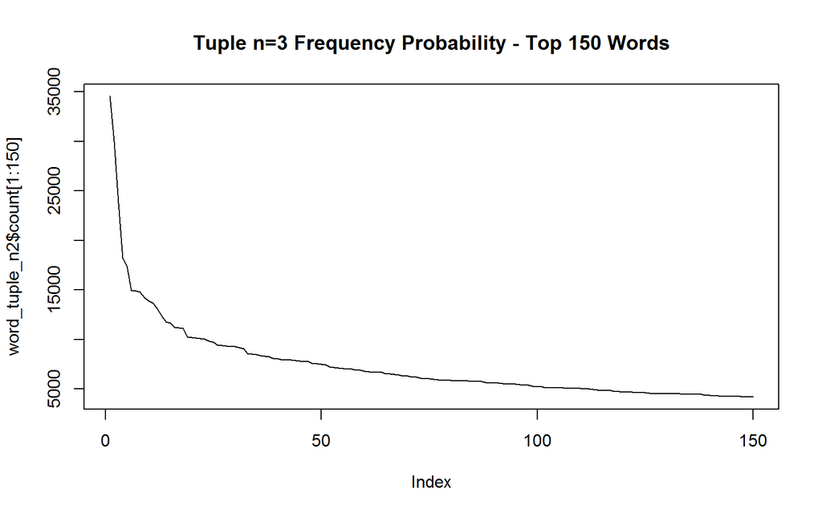

```r
plot(word_tuple_n2$count[1:150], type = 'l',
     main = "Tuple n=3 Frequency Probability - Top 150 Words")
```

The comparative dropoff is much less on the same 150 word scale. When it is possible to make predictions based on recurring phrases, the expectation is increased accuracy. However, this will require a tradeoff of performance and memory as tuple probabilities require holding several orders of magnitude more data in memory and search through it to make the most probable predictions.

**Planned Application Architecture**

The application will use a waterfall format. When given a phrase, the application will make 5 predictions as to the next word. The predictions will be made in order from the following component analytics in order of frequency: * Predictions for all matching n=4 tuples (3 key, 1 value) * Predictions for all matching n=3 tuples (2 key, 1 value) * Predictions for all matching n=2 tuples (1 key, 1 value) * Predictions for most common used words by flat frequency.

All duplicate predictions will be removed, to ensure that 5 unique predictions are made for all entries. Additionally, the application will skip any prediction sub-models in the waterfall that are not possible (e.g. 3 key predictions when only 2 words have been typed so far).

*Data Size:* They constraints of the application design under this architechure is the data size and integration into the shiny application. To make the absolute most accurate predictions in all scenarios, inclusion of all tuple frequencies as large as computable would be available. However, this will be too large for the Shiny environment to handle, and will likely cause lag in predictions from the models making the end user wait time too long. Additionally, the Shiny source code will not be able to natively include the data at that scale, and will need to integrate with data stored in a cloud location (Dropbox, or the like) if necessary to the application performance. Thus, the application will be developed to rely primarily on outside data integration from the cloud, but will remain operational if such data is no longer available.